# Lab #0: Getting Going

This exercise will take two weeks because of the holiday during Week 2 which will cause Monday classes to be taught on Tuesday and our Tuesday labs to not happen. The work is to be completed by teams as directed by your lab instructor. You will be introduced to MicroPython programming, and you will begin learning to control the world like a Python.

| **Schedule** |  |
| --- | --- |
| Week 1 | Set up Thonny; write and test program with hardware |
| Week 2 | Set up Doxygen and Git; compile documents and put in The Cloud |

## Downloads

All the software used in this course is free and available for Linux, MacOS™, and Windows Vista™ Service Pack 7, 8, 10, or 11 operating systems. You’ll need at least the following software for ME405, and the procedures for the labs will help you install and configure them:

- A Python Integrated Development Environment (IDE). There are dozens available. We will support Thonny, https://thonny.org as our first choice IDE because it is designed for Python beginners and works efficiently with MicroPython boards. Other IDEs such as Spyder, PyCharm™, VSCode™, Idle, and Eric may be used, but the workflow is slower and more complex.
- The Doxygen documentation generator.
- GitHub Desktop, combined with an account on GitHub™. If you’re already accustomed to SourceTree™, you can use that, though it’s not as well integrated with the `Hub. Each lab team will be required to have a set of repositories on GitHub, and we’ll set up your accounts in a subsequent lab.

There is other recommended software, such as interfaces for a logic analyzer and/or USB oscilloscope, a complete Python development system such as Anaconda™, *etc.*

## Familiarization

The following procedure is intended to get you up to speed quickly with the programming tools used in the lab. The microcontroller platforms we use are made with low-cost commercial circuits and one custom board which is open-source hardware; you are welcome to download and assemble your own. See https://spluttflob.github.io/ME405-Support/shoe_info.html for information on the custom board.

- Install and run Thonny according to the instructions in the page **Using the Thonny Python IDE** on the course Cantvas site. Choose the MicroPython interpreter.
- You should have a terminal window below Thonny’s text editor window; try typing some lines of code at the `>>>` prompt (you needn’t type the comments yet). For example:

  ```python
  print("Hello, Milky Way")                           # A comment
  print("The answer is {:d}".format (42))
  for count in range(12):
      print (count)                  # Must get indentation right
  ```

  This is mechatronics, so let’s control a digital output pin. Connect an oscilloscope probe’s ground lead to the header pins near the corner of the Nucleo with the triangular blue “Don’t touch” symbol. Connect the probe tip to the pin labeled `A5` near the opposite corner of the board (often it helps to use a small wire clamped by the `scope tip and plugged into`A5`). Then run the following code:

  ```python
  pinC0 = pyb.Pin(pyb.Pin.board.PC0, pyb.Pin.OUT_PP)
  pinC0.value(1)
  pinC0.value(0)
  ```

  Look at the **STM32L476RG Nucleo Arduino Pins** image on Cantvas to see which pins are where. *Ignore* the Arduino pin markers *A0 – A5* and *D0 – D15.*
- Now try another pin as an *analog* (sort of) rather than digital output. The following code allows you to set up the pin to produce pulse a width modulated (PWM) waveform:

  ```python
  pinA1 = pyb.Pin(pyb.Pin.board.PA1, pyb.Pin.OUT_PP)
  tim2 = pyb.Timer(2, freq=20000)
  ch2 = tim2.channel(2, pyb.Timer.PWM, pin=pinA1)
  ch2.pulse_width_percent(30)
  ```

  Connect an oscilloscope from ground to the pin labeled `A1` on the Nucleo. Call function `ch2.pulse_width_percent(`*`n`*`)` several times, changing the percentage *n* between 0 and 100, and watch how the signal changes.
- How about using an analog to digital converter (ADC) to measure a voltage:

  ```python
  adc0 = pyb.ADC(pyb.Pin.board.PC0)
  print(adc0.read())
  ```

- There is a quick reference page at:  
  https://spluttflob.github.io/ME405-Support/index.html

## Organization

Next you’ll write some programs. The program code and documentation for your labs should be organized on your computer(s) and linked to repositories on GitHub™ which make your work available for yourself and others in the future.

- Set up a directory structure in a convenient place on your computer such as your `Documents` folder. Each lab exercise will have one directory named `LabN` and each lab directory will contain a subdirectory called `src` and another called `docs`. The structure should look like the following:

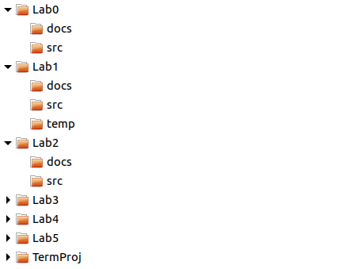

  Each of the directories `Lab0`, `Lab1`, *etc.* will be set up as a Git repository and mirrored in The Cloud on GitHub.

## Week 1: Measure a Physical Thing

We will measure a voltage which changes in a similar way as the speed of a DC motor, the temperature of an oven, and many other mechanical quantities change – as first-order linear systems.

1. Find two resistors, one **R** ≈ 100KΩ and the other approximately 5KΩ, and a capacitor *C* ≈ 3.3µF. These should be in the small parts box in your ME405 kit; if not, check the blue cabinet full of resistors. Connect them to your Nucleo with the input coming from pin `C0` (marked as A5 on the circuit board) and the output going to pin `B0` (marked as A3).

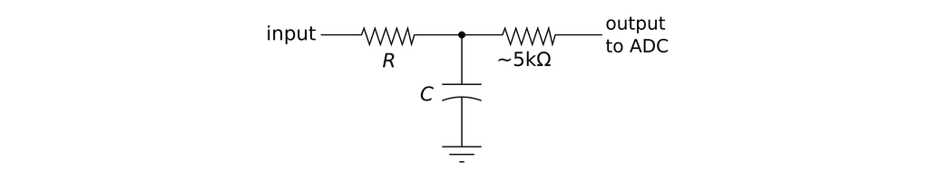

   Printing something distinctive such as `End` when the test is over will make the next steps easier.

   Your program needs to take measurements at precise time intervals – more precise than can be done with regular loops. You’ll need to use a timer interrupt.

> **We Interrupt this Program…**

> For accurate timing of fast measurements, you’ll need to use timer interrupts rather than a simple loop. This is done in MicroPython by writing an *interrupt callback function* in Python and configuring an interrupt source to run it. Using interrupts in MicroPython is easier than doing so in assembly or C language, but there are restrictions on MicroPython interrupt code:
> - Floating point math must not be done in an interrupt callback.
> - No memory may be allocated in the callback. This includes appending or inserting items to lists or arrays. Changing values inside already allocated variables, arrays, or queues is okay.
> - Printing from within an interrupt callback is unreliable and should not be done except temporarily for debugging. Putting characters into a queue to be printed in non-interrupt code is OK.
> - Data transferred between interrupt and non-interrupt code must be protected from corruption due to the interrupt process.

> MicroPython interrupt callbacks are like interrupt handlers in any other language in that they should be simple and run quickly. Interrupt callbacks can print exception messages if the following code is included near the beginning of your program:

> ```
>  import micropython
>  micropython.alloc_emergency_exception_buf(100)
> ```

4. When your program takes measurements inside the interrupt callback function, how does it get those measurements to the non-interrupt part without corruption as mentioned above? One good answer is to use a *queue*. We have a class called `cqueue.IntQueue` in the ME405 version of MicroPython which does this. See the documentation of `IntQueue` at:  
   https://spluttflob.github.io/ME405-Support/classcqueue_1_1IntQueue.html
5. Your MicroPython program should be organized as shown in the example below:

   ```python
     """! @file main.py
     Doxygen style docstring for the file
     """

     def timer_int(tim_num):
         """!
         Doxygen style docstring for interrupt callback function
         """
         # Code goes here


     def step_response (...parameters...):
         """!
         Doxygen style docstring for this function
         """
         # Function code here


     if __name__ == "__main__":
         step_response(...parameters...)
   ```

   Notice the Doxygen formatted comment strings; these are required.

   The example file `the_answer.py` on Cantvas shows a more detailed example of how the file should be organized.

   **Checkpoint:** Show your instructor your program as it runs, performing a step response test and printing the resulting times and voltages.
6. Install Doxygen using the instructions in the page **Installing and Using Doxygen** on Cantvas.
7. If you haven’t already written Doxygen format comments for your Python files and the functions therein, you should have…so do so now.
8. Run Doxygen to create the directory called `<your_project_dir>/docs` containing documentation for your functions.
9. For Week 1, make a compressed `.zip` archive file containing your `Lab0` directory and all the files and subdirectories within it. This should include your `src` directory as well as the `docs` directory full of HTML files.

## Week 2: PC Interface and Simulation

1. Write a CPython program which runs on a laptop or desktop and provides a user interface for your step response program. The interface program should send a signal through the USB-serial port that causes the microcontroller to run a step response and print the results. The results should be read by the interface program, converted from arrays of characters to floating point numbers, put into lists, and plotted using Matplotlib. Of course, any plot *must* have a title and labeled axes with units, right?

   An example program has been provided which shows how to create a simple Graphical User Interface (GUI) window containing your plot and some buttons to control the test. Modify the example so that it runs a step response test and plots the result. Save a good plot for inclusion on your README page (see **Deliverables** below).

#### Hints

   - When MicroPython uses `print()` it sends characters through the USB-serial port. To receive those characters on a PC, use the `Serial` class in the `serial` module. Search for `pyserial` on the Web for references.
   - The serial port method `readline()` is recommended for getting printed text from the USB-serial port. Expect to use string methods such as `strip()` and `split()` to isolate strings containing numbers and the `float()` function to find numbers in those strings.
   - When you disconnect Thonny from the microcontroller, MicroPython is left in “Raw REPL” mode, and your program will have a hard time talking to it. Sending a control-B character gets the microcontroller back in regular REPL mode; control-C stops any running program; control-D reboots the microcontroller *and causes `main.py` to run.*  
     Some combination of these keys will probably be helpful.
   - Remember how you printed `End`? It will be helpful now.
   - Sometimes there are errors in transmission. Using a `try`–`except`–`else` structure allows us to reject bad data while keeping good data.
2. Following the style of the example, add a second curve to your plot: A simulated *V<sub>MAX</sub>* (1 - e<sup>-t/RC</sup>) curve made from the values of *V<sub>MAX</sub>*, *R*, and *C* in your circuit. Note:
   - The ~5K resistor is *not* part of this equation because negligible current flows through it.
   - It’s traditional to show measured data as points and theoretical curves with lines.

#### Cloud Storage

For Week 2 and thereafter, all submissions of program code and Doxygen documentation will be made by pushing the files to your team’s GitHub™ account.

- At least one member of your lab team should set up an account on GitHub™ with a `Lab_0` repository in it. Follow the instructions in the page **Using Git in ME405** to put your project on this GitHub site.
- Everyone on the team should download and install the GitHub Desktop™ application on her or his computer. See the instructions in the page **Using Git in ME405** on Cantvas.

## Deliverables

#### By the Beginning of Lab Time on Week 2

- Upload your `zip` file containing your source code and documentation for your MicroPython program to the Week 1 Cantvas assignment.

#### By the Beginning of Lab on Week 3

- After setting up your team’s GitHub account and making a `Lab 0` repository there, commit and push at least one revision (preferably more) of your source code to the `Hub.
- Make sure your Doxygen documentation is in folder `docs` and the GitHub Pages for your repository shows the Doxygen pages.
- Add a short and simple `README.md` which describes what your program does and shows the result of a step response test plus theoretical curve.